# Assigment 2

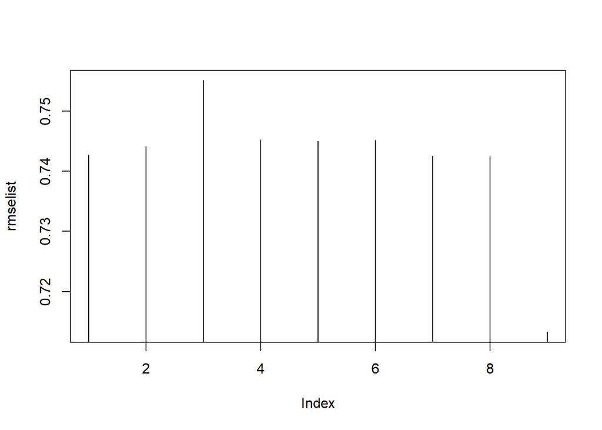

```r
plot(rmselist, type="h")
```

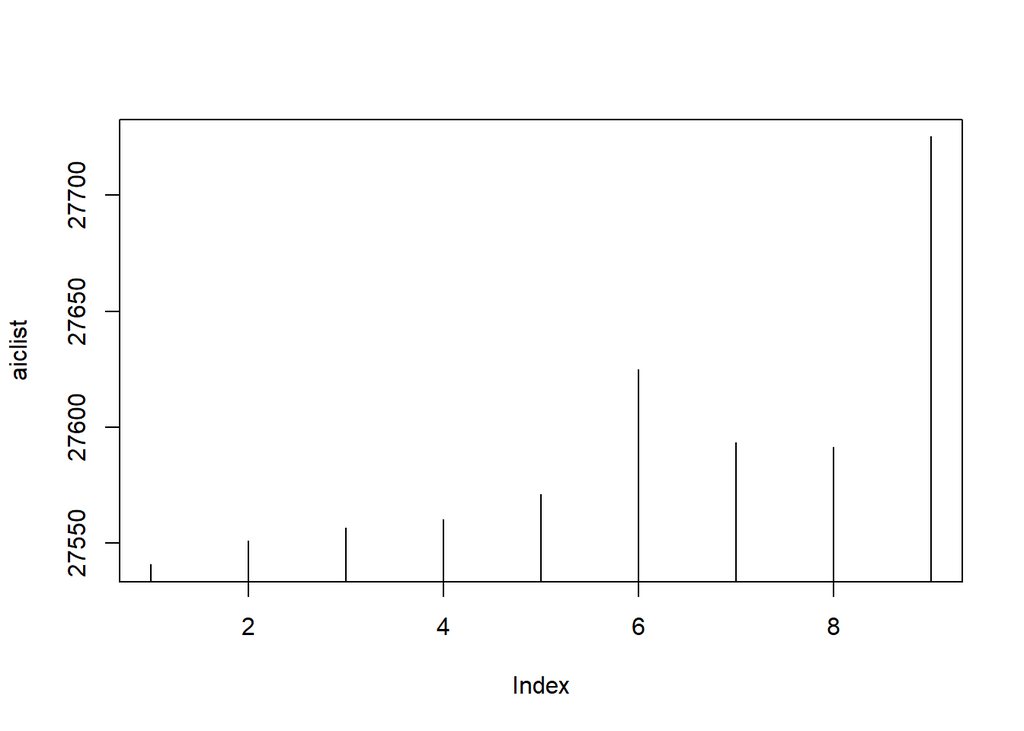

```r
plot(aiclist, type= "h")
```

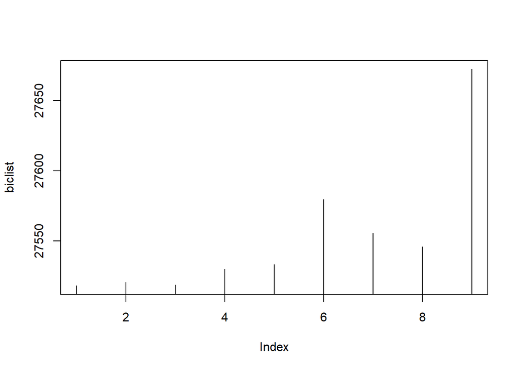

```r
plot(biclist, type="h")
```

```r
order=c(3,0,1)
dtb3fit=armafit(DTB3, order)
stargazer(dtb3fit, type="text")
```

```
##
## =============================================
##                       Dependent variable:
##                   ---------------------------
##                             armats
## ---------------------------------------------
## ar1                        0.685***
##                             (0.096)
##
## ar2                        0.397***
##                             (0.108)
##
## ar3                        -0.082***
##                             (0.014)
##
## ma1                        0.449***
##                             (0.096)
##
## ---------------------------------------------
## Observations                17,855
## Log Likelihood            19,073.000
## sigma2                       0.007
## Akaike Inf. Crit.         -38,136.000
## =============================================
## Note:             *p<0.1; **p<0.05; ***p<0.01
```

We see that mae chooses model 3, rmse chooses model 9, both aic and bic choose model 1. As a tradeoff between complexity and fitting, we select model 3.

We use the same Procedure for DGS2

```r
dgs2train=DGS2[1:(length(DGS2)*0.8)]
dgs2test=DGS2[((length(DGS2)*0.8)+1):length(DGS2)]

order=ordercomb[1,]
fit=armafit(dgs2train,order)
fitpred=predict(fit,n.ahead=length(dgs2test), interval="confidence")
mae=mae(dgs2test,fitpred$pred)
rmse=rmse(dgs2test,fitpred$pred)


maelist=c()
rmselist=c()
aiclist=c()
biclist=c()
for (c in 1:nrow(ordercomb)){
  order=ordercomb[c,]
  fit=armafit(dgs2train,order)
  fitpred=predict(fit,n.ahead=length(dgs2test), interval="confidence")
  maelist[c]=mae(dgs2test,fitpred$pred)
  rmselist[c]=rmse(dgs2test,fitpred$pred)
  aiclist[c]=-1*AIC(fit)
  biclist[c]=-1*BIC(fit)
}

errorlist=cbind(maelist, rmselist, aiclist, biclist)
which.min(errorlist[,1])
```

```
## [1] 9
```

```r
which.min(errorlist[,2])
```

```
## [1] 9
```

```r
which.min(errorlist[,3])
```

```
## [1] 1
```

```r
which.min(errorlist[,4])
```

```
## [1] 9
```

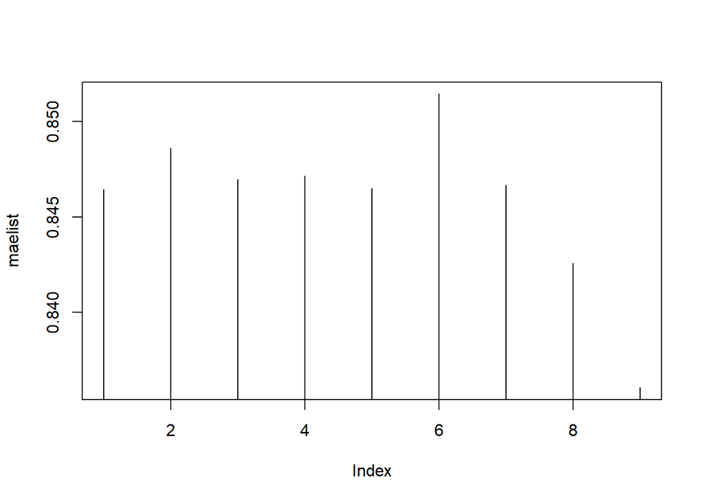

```r
plot(maelist, type= "h")
```

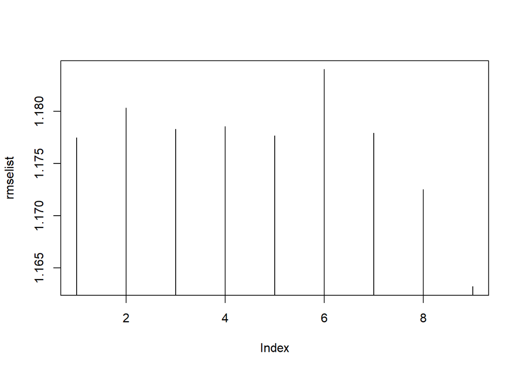

```r
plot(rmselist, type="h")
```

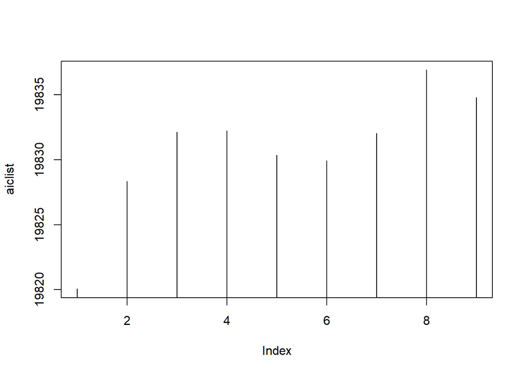

```r
plot(aiclist, type= "h")
```

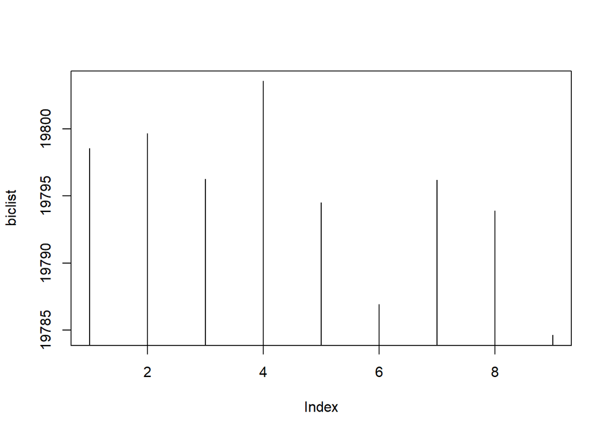

```r
plot(biclist, type="h")
```

```r
order=c(1,0,1)
dgs2fit=armafit(DGS2, order)
stargazer(dgs2fit, type="text")
```

```
##
## =============================================
##                       Dependent variable:
##                   ---------------------------
##                             armats
## ---------------------------------------------
## ar1                        1.000***
##                            (0.0001)
##
## ma1                        0.073***
##                             (0.009)
##
## ---------------------------------------------
## Observations                12,009
## Log Likelihood            13,503.590
## sigma2                       0.006
## Akaike Inf. Crit.         -27,001.170
## =============================================
## Note:             *p<0.1; **p<0.05; ***p<0.01
```

We see that only aic chooses model instead of model 9. Considering the high complexity of model 9, we opt for model 1.

And the same procedure for DGS10

```r
dgs10train=DGS10[1:(length(DGS10)*0.8)]
dgs10test=DGS10[((length(DGS10)*0.8)+1):length(DGS10)]

order=ordercomb[1,]
fit=armafit(dgs10train,order)
fitpred=predict(fit,n.ahead=length(dgs10test), interval="confidence")
mae=mae(dgs10test,fitpred$pred)
rmse=rmse(dgs10test,fitpred$pred)


maelist=c()
rmselist=c()
aiclist=c()
biclist=c()
for (c in 1:(nrow(ordercomb)-1)){
  order=ordercomb[c,]
  fit=armafit(dgs10train,order)
  fitpred=predict(fit,n.ahead=length(dgs10test), interval="confidence")
  maelist[c]=mae(dgs10test,fitpred$pred)
  rmselist[c]=rmse(dgs10test,fitpred$pred)
  aiclist[c]=-1*AIC(fit)
  biclist[c]=-1*BIC(fit)
}

errorlist=cbind(maelist, rmselist, aiclist, biclist)
which.min(errorlist[,1])
```

```
## [1] 2
```

```r
which.min(errorlist[,2])
```

```
## [1] 2
```

```r
which.min(errorlist[,3])
```

```
## [1] 2
```

```r
which.min(errorlist[,4])
```

```
## [1] 2
```

```r
ordercomb
```

```
##       [,1] [,2] [,3]
##  [1,]    1    0    1
##  [2,]    2    0    1
##  [3,]    3    0    1
##  [4,]    1    0    2
##  [5,]    2    0    2
##  [6,]    3    0    2
##  [7,]    1    0    3
##  [8,]    2    0    3
##  [9,]    3    0    3
```

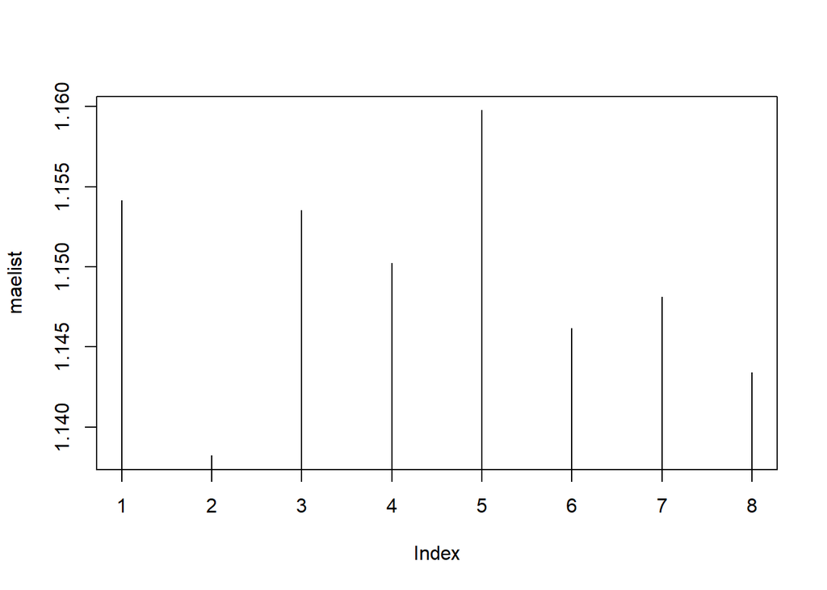

```r
plot(maelist, type= "h")
```

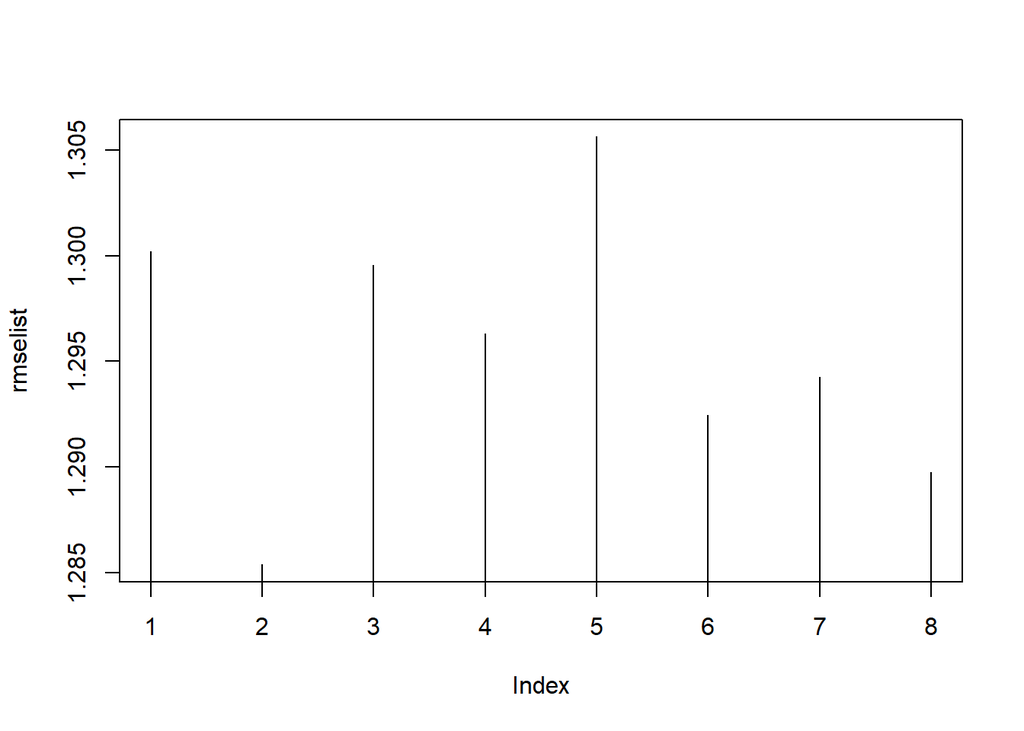

```r
plot(rmselist, type="h")
```

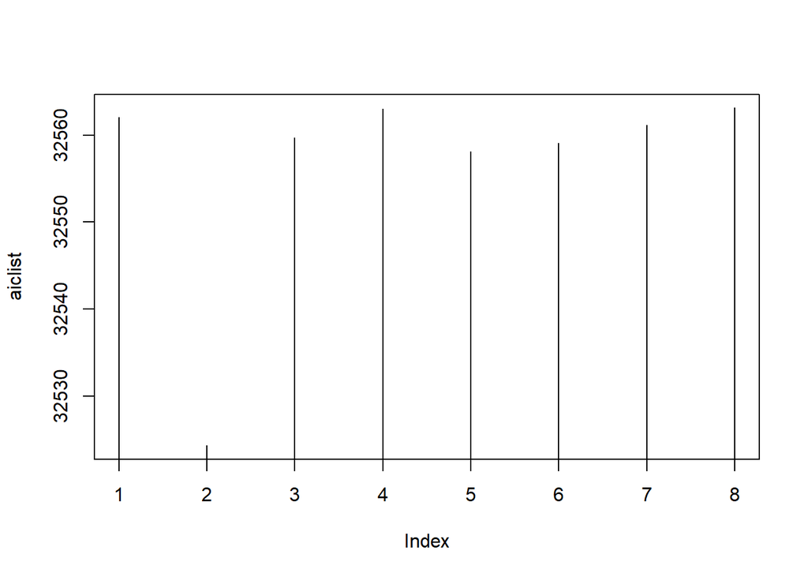

```r
plot(aiclist, type= "h")
```

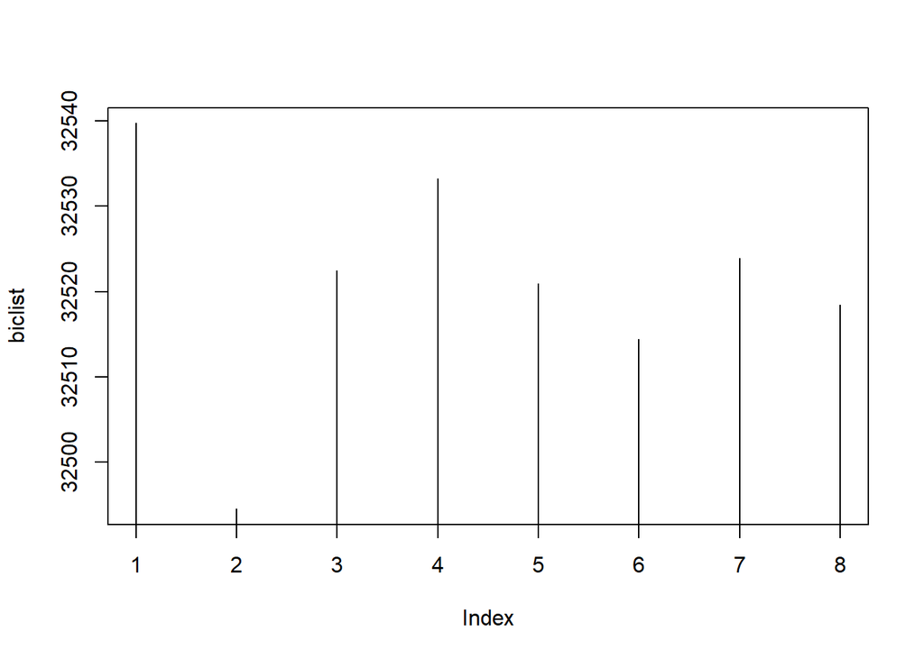

```r
plot(biclist, type="h")
```

```r
order=c(2,0,1)
dgs10fit=armafit(DGS10, order)
stargazer(dgs10fit, type="text")
```

```
##
## =============================================
##                       Dependent variable:
##                   ---------------------------
##                             armats
## ---------------------------------------------
## ar1                        1.172***
##                             (0.122)
##
## ar2                         -0.172
##                             (0.122)
##
## ma1                         -0.113
##                             (0.123)
##
## ---------------------------------------------
## Observations                15,769
## Log Likelihood            21,127.360
## sigma2                       0.004
## Akaike Inf. Crit.         -42,246.710
## =============================================
## Note:             *p<0.1; **p<0.05; ***p<0.01
```

Here all measures point to model 2 being the best specification possible. Thus we choose model 2.

```r
adf.test(DTB3)
```

```
## Augmented Dickey-Fuller Test
## alternative: stationary
##
## Type 1: no drift no trend
##       lag   ADF p.value
##  [1,]   0 1.073   0.923
##  [2,]   1 0.897   0.901
##  [3,]   2 0.888   0.899
##  [4,]   3 0.943   0.907
##  [5,]   4 0.912   0.903
##  [6,]   5 0.808   0.876
##  [7,]   6 0.840   0.886
##  [8,]   7 0.827   0.882
##  [9,]   8 0.842   0.886
## [10,]   9 0.845   0.887
```

[output cut: 35 more lines]

```r
adf.test(DGS2)
```

```
## Augmented Dickey-Fuller Test
## alternative: stationary
##
## Type 1: no drift no trend
##       lag   ADF p.value
##  [1,]   0 0.286   0.726
##  [2,]   1 0.262   0.719
##  [3,]   2 0.251   0.716
##  [4,]   3 0.269   0.721
##  [5,]   4 0.268   0.721
##  [6,]   5 0.259   0.719
##  [7,]   6 0.249   0.716
##  [8,]   7 0.239   0.713
##  [9,]   8 0.218   0.707
## [10,]   9 0.227   0.709
```

[output cut: 32 more lines]

```r
adf.test(DGS10)
```

```
## Augmented Dickey-Fuller Test
## alternative: stationary
##
## Type 1: no drift no trend
##       lag   ADF p.value
##  [1,]   0 0.538   0.799
##  [2,]   1 0.505   0.789
##  [3,]   2 0.503   0.789
##  [4,]   3 0.501   0.788
##  [5,]   4 0.506   0.790
##  [6,]   5 0.494   0.786
##  [7,]   6 0.490   0.785
##  [8,]   7 0.478   0.781
##  [9,]   8 0.480   0.782
## [10,]   9 0.486   0.784
```

[output cut: 35 more lines]

```r
modelterm=lm(DGS10 ~ DTB3[2087:length(DTB3)])
adf.test(as.numeric(modelterm$residuals))
```

```
## Augmented Dickey-Fuller Test
## alternative: stationary
##
## Type 1: no drift no trend
##       lag   ADF p.value
##  [1,]   0 -4.07    0.01
##  [2,]   1 -4.44    0.01
##  [3,]   2 -4.45    0.01
##  [4,]   3 -4.28    0.01
##  [5,]   4 -4.22    0.01
##  [6,]   5 -4.52    0.01
##  [7,]   6 -4.38    0.01
##  [8,]   7 -4.28    0.01
##  [9,]   8 -4.23    0.01
## [10,]   9 -4.27    0.01
```

[output cut: 35 more lines]

```r
modelterm2=lm(DGS10[3761:length(DGS10)] ~ DGS2)
adf.test(as.numeric(modelterm2$residuals))
```

```
## Augmented Dickey-Fuller Test
## alternative: stationary
##
## Type 1: no drift no trend
##       lag   ADF p.value
##  [1,]   0 -2.97    0.01
##  [2,]   1 -2.99    0.01
##  [3,]   2 -3.00    0.01
##  [4,]   3 -2.89    0.01
##  [5,]   4 -2.86    0.01
##  [6,]   5 -2.87    0.01
##  [7,]   6 -2.92    0.01
##  [8,]   7 -2.93    0.01
##  [9,]   8 -2.95    0.01
## [10,]   9 -2.97    0.01
```

[output cut: 32 more lines]

Noting that the two time series are non-stationary, we know that there is cointegration between their components.